# iLykei Lecture Series Machine Learning Workshop Neural Networks

Y.Balasanov, L.Nazarov, © iLykei 2018-2020

# 1 Introduction

For this topic the following materials might be useful.

An online book by Michael Nielsen: [Neural Networks and Deep Learning](http://neuralnetworksanddeeplearning.com/index.html).

University of Cambridge course [Advanced Pattern Processing](http://mi.eng.cam.ac.uk/~mjfg/local/I10/i10_hand4.pdf).

# 2 Neural Network Packages in R

R has several packages for dealing with NNs, like **neuralnet**, **nnet** or **RSNNS**.

Package **neuralnet**.  
Description: Training of neural networks using backpropagation, resilient backpropagation with (Riedmiller, 1994) or without weight backtracking (Riedmiller and Braun, 1993) or the modified globally convergent version by Anastasiadis et al. (2005). The package allows flexible settings through custom-choice of error and activation function. Furthermore, the calculation of generalized weights (Intrator O & Intrator N, 1993) is implemented.  
Reference manual: neuralnet.pdf

Package **nnet**.  
Description: Software for feed-forward neural networks with a single hidden layer, and for multinomial log-linear models.  
Reference manual: nnet.pdf

The methods implemented in the above packages are available in the **caret** package framework. **caret** uses **nnet** both for classification and regression, **neuralnet** only for regression.

# 3 Regression

## 3.1 Simple Example 1

```r
library(neuralnet)
library(boot)
```

Create a simple example with the following data which define **Or Logic Gate**.

```r
(da<-data.frame(x1=c(0,0,1,1),x2=c(0,1,0,1),y=c(0,1,1,1)))
```

```
##   x1 x2 y
## 1  0  0 0
## 2  0  1 1
## 3  1  0 1
## 4  1  1 1
```

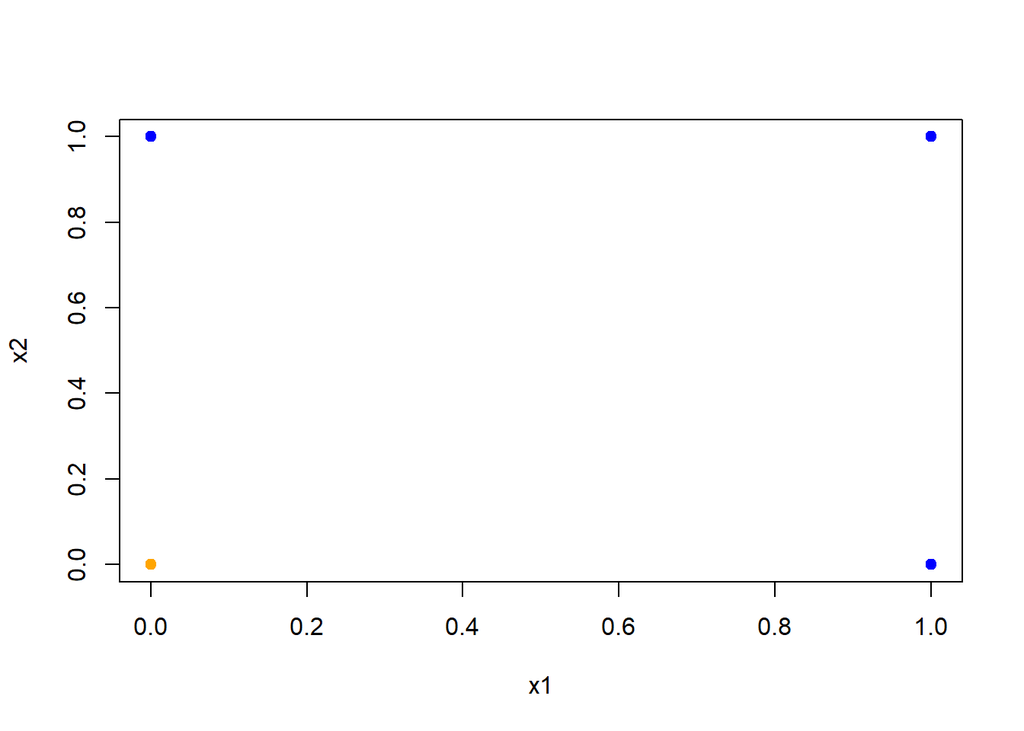

```r
plot(subset(da,y==1)[,1:2],pch=19,col="blue")
points(subset(da,y==0)[,1:2],pch=19,col="orange")
```

Train perceptron neural net with default architecture of layers.

```r
set.seed(14)
nnDa <- neuralnet(y~x1+x2,data=da, err.fct="sse",rep=2)
names(nnDa)
```

```
##  [1] "call"                "response"            "covariate"
##  [4] "model.list"          "err.fct"             "act.fct"
##  [7] "linear.output"       "data"                "exclude"
## [10] "net.result"          "weights"             "generalized.weights"
## [13] "startweights"        "result.matrix"
```

Function `print(nnDa)` gives complete, but pretty long information about the trained network.  
Plotting the network structure is done by:

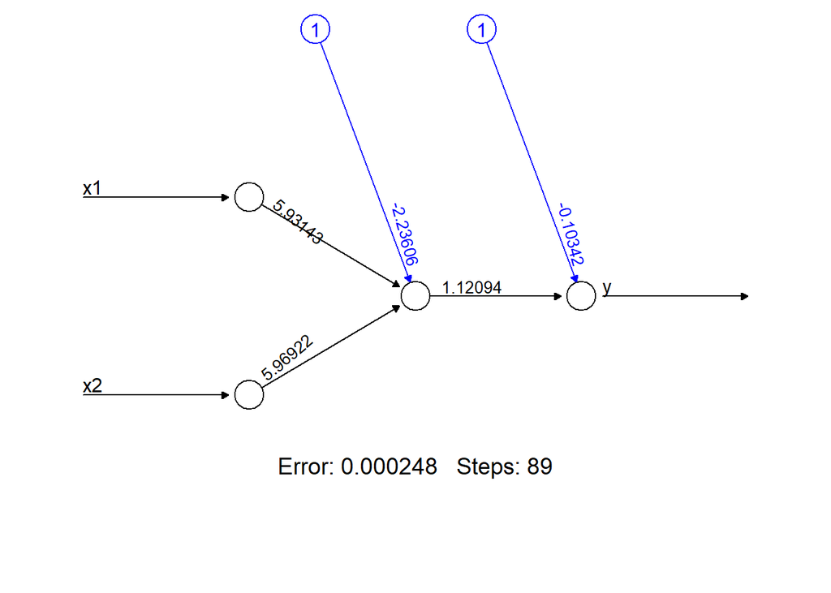

```r
plot(nnDa,rep="best")
```

By default function `neuralnet()` uses activation function inverse logit function $g(u)=\frac{1}{1+exp(-u)}$.

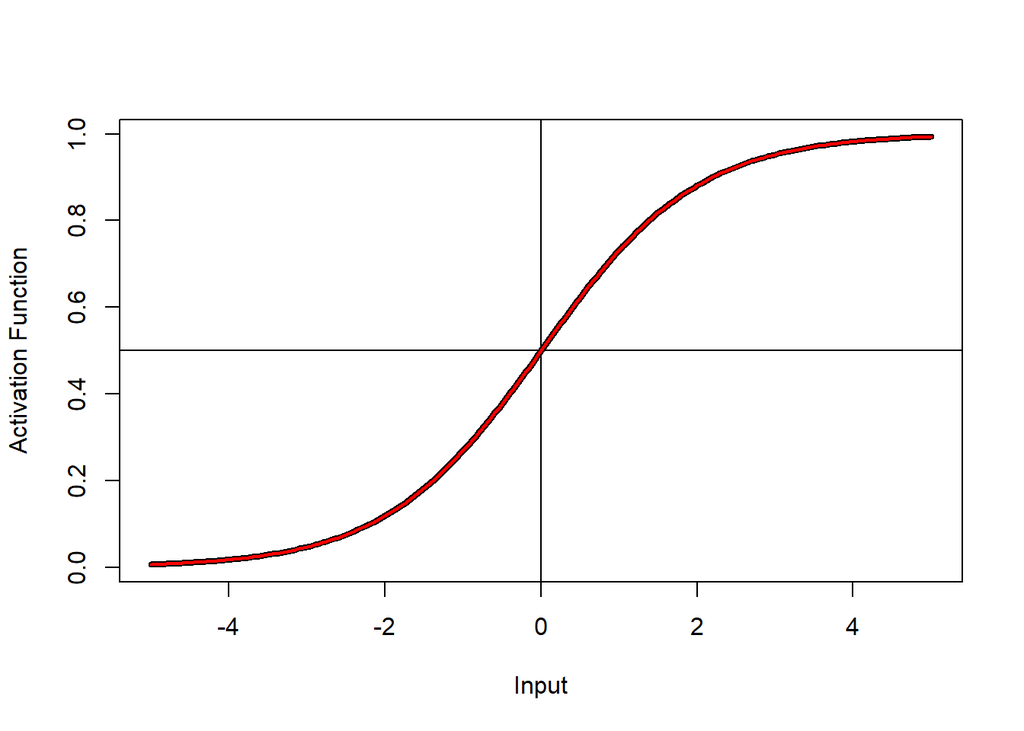

```r
vr<-seq(from=-5,to=5,by=.05)
plot(vr,nnDa$act.fct(vr),type="l",ylab="Activation Function",xlab="Input",lwd=4)
abline(v=0)
abline(h=.5)
lines(seq(from=-5,to=5,by=.05),1/(1+exp(-vr)),col="red",lwd=2)
```

Look at the results of training.  
Field `result.matrix` of the object contains all main characteristics of the neural network by repetition.

```r
nnDa$result.matrix
```

```
##                                [,1]          [,2]
## error                  0.0002478762  0.0009504074
## reached.threshold      0.0039233994  0.0034301613
## steps                 89.0000000000 43.0000000000
## Intercept.to.1layhid1 -2.2360570180 -0.9557604235
## x1.to.1layhid1         5.9314312771  4.1351192315
## x2.to.1layhid1         5.9692212313  4.2741937305
## Intercept.to.y        -0.1034243712 -0.3900286578
## 1layhid1.to.y          1.1209353689  1.4251036444
```

The matrix shows which repetition was better (by the value of error): 1.

In `net.result` find the estimated output by repetition.  
In `weights` find the weights and intercepts.

```r
nnDa$net.result
```

```
## [[1]]
##             [,1]
## [1,] 0.004811985
## [2,] 0.991327770
## [3,] 0.990343813
## [4,] 1.017439832
##
## [[2]]
##             [,1]
## [1,] 0.005762287
## [2,] 0.985275874
## [3,] 0.978142212
## [4,] 1.034249789
```

```r
nnDa$weights
```

```
## [[1]]
## [[1]][[1]]
##           [,1]
## [1,] -2.236057
## [2,]  5.931431
## [3,]  5.969221
##
## [[1]][[2]]
##            [,1]
## [1,] -0.1034244
## [2,]  1.1209354
##
##
## [[2]]
## [[2]][[1]]
##            [,1]
## [1,] -0.9557604
## [2,]  4.1351192
## [3,]  4.2741937
##
## [[2]][[2]]
##            [,1]
## [1,] -0.3900287
## [2,]  1.4251036
```

Reproduce the output from `net.result` using the estimated coefficients of the net.  
Use the best repetition.

```r
(repBest<-which.min(nnDa$result.matrix[1,]))
```

```
## [1] 1
```

```r
(weightsX<-nnDa$weights[[repBest]][[1]][-1])
```

```
## [1] 5.931431 5.969221
```

```r
matrX<-as.matrix(da[,1:2])
manualOutput<-plogis(matrX%*%weightsX+nnDa$weights[[repBest]][[1]][1])*
  nnDa$weights[[repBest]][[2]][2]+nnDa$weights[[repBest]][[2]][1]
cbind(manualOutput=manualOutput,NnetOutput=nnDa$net.result[[repBest]])
```

```
##             [,1]        [,2]
## [1,] 0.004811985 0.004811985
## [2,] 0.991327770 0.991327770
## [3,] 0.990343813 0.990343813
## [4,] 1.017439832 1.017439832
```

```r
predict(nnDa,da[,1:2])
```

```
##             [,1]
## [1,] 0.004811985
## [2,] 0.991327770
## [3,] 0.990343813
## [4,] 1.017439832
```

```r
compute(nnDa,da[,1:2])
```

```
## $neurons
## $neurons[[1]]
##        x1 x2
## [1,] 1  0  0
## [2,] 1  0  1
## [3,] 1  1  0
## [4,] 1  1  1
##
## $neurons[[2]]
##      [,1]       [,2]
## [1,]    1 0.09655896
## [2,]    1 0.97664163
## [3,]    1 0.97576383
## [4,]    1 0.99993651
##
##
## $net.result
##             [,1]
## [1,] 0.004811985
## [2,] 0.991327770
## [3,] 0.990343813
## [4,] 1.017439832
```

Note that sigmoid activation function is only applied to the output of the hidden layer. This is because by default `neuralnet()` has argument `linear.output=TRUE` which means that output layer has no activation function. Change it to `FALSE` if application of sigmoid to output is necessary.

Function `compute()` computes the outputs of all neurons for specific arbitrary covariate vectors given a trained neural network (like `predict()`).

### 3.1.1 Comparison with logistic regression

The fitted neural network implements the formulas:

$$\eta=\beta_{0,2}+\beta_{1,2}(\beta_{0,1}+\beta_{1,1}x_1+\beta_{2,1,}x_2)$$
$$=(\beta_{0,2}+\beta_{1,2}\beta_{0,1})+(\beta_{1,2}\beta_{1,1})x_1+(\beta_{1,2}\beta_{2,1,})x_2$$
$$=B_0+B_1x_1+B_2x_2,$$
where

$\beta_{0,2}=$ -0.1034244  
$\beta_{1,2}=$ 1.1209354  
$\beta_{0,1}=$ -2.236057  
$\beta_{1,1}=$ 5.9314313  
$\beta_{2,1}=$ 5.9692212

and

$B_0=\beta_{0,2}+\beta_{1,2}\beta_{0,1}=$ -0.1034244 $+$ 1.1209354 $\times$ -2.236057 $=$ -2.6098998

$B_1=\beta_{1,2}\beta_{1,1}=$ 1.1209354 $\times$ 5.9314313 $=$ 6.6487511

$B_2=\beta_{1,2}\beta_{2,1,}=$ 1.1209354 $\times$ 5.9692212 $=$ 6.6911112

That is: linear predictor $\eta$ is estimated as $\eta=B_0+B_1x_1+B_2x_2$.  
The output of the network $y$ goes through activation function (**axon hillock**) of the form of inverse logit function $g(u)=\frac{1}{1+e^{-u}}$, i.e

$$\frac{1}{1+exp(-\eta)}=\frac{e^{\eta}}{1+e^{\eta}}.$$

**But this is formula for probability of logistic regression!**

This means that neural network with one perceptron and default configuration with no hidden layers with inverse logit activation function must be equivalent to logistic regression

$$\ln \left( \frac{p}{1-p} \right)=B_0+B_1x_1+B_2x_2.$$

For comparison with logistic regression calculate predictions given by perceptron:

1. Coefficients.

```r
B_0<-nnDa$weights[[1]][[2]][1]+nnDa$weights[[1]][[2]][2]*nnDa$weights[[1]][[1]][1]
B_1<-nnDa$weights[[1]][[2]][2]*nnDa$weights[[1]][[1]][2]
B_2<-nnDa$weights[[1]][[2]][2]*nnDa$weights[[1]][[1]][3]
```

2. Linear predictor.

```r
manPred<-B_0+B_1*da$x1+B_2*da$x2
```

3. Probabilities of success.

```r
predNeuron<-nnDa$act.fct(manPred)
```

Probabilities estimated by logistic regression:

```r
Logistic<-glm(y~x1+x2,data=da,family=binomial)
LogisticCoeff<-Logistic$coefficients
```

Compare coefficients.

```r
cbind(Logistic=LogisticCoeff,Neuron=c(B_0,B_1,B_2))
```

```
##             Logistic    Neuron
## (Intercept) -23.3595 -2.609900
## x1           46.7190  6.648751
## x2           46.7190  6.691111
```

Coefficients do not look the same.  
But check predicted probabilities.

```r
PredLogistic<-predict(Logistic,type="response")
cbind(Neuron=predNeuron,Logistic=PredLogistic)
```

```
##      Neuron     Logistic
## 1 0.0685040 7.163054e-11
## 2 0.9833934 1.000000e+00
## 3 0.9826873 1.000000e+00
## 4 0.9999781 1.000000e+00
```

**Note that neural network fits with 5 parameters while logistic regression fits with 3 parameters**.

### 3.1.2 Remove unnecessary parameters and force perceptron to fit more accurately

In order to better reproduce the results of logistic regression do the following:

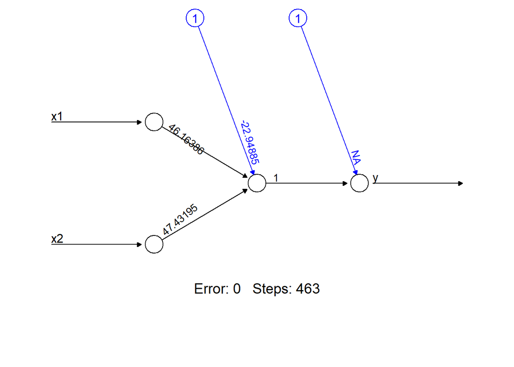

```r
set.seed(14)
nnDa <- neuralnet(y~x1+x2,data=da, err.fct="sse",rep=10, exclude=c(4,5),
                  constant.weights = c(0,1),threshold=1e-20)
plot(nnDa,rep="best")
```

Compare the coefficients with fitted logistic regression

```r
LogisticCoeff
```

```
## (Intercept)          x1          x2
##    -23.3595     46.7190     46.7190
```

## 3.2 Simple Example 2

Fit neural network to data representing **And Logic Gate**

```r
(da<-data.frame(x1=c(0,0,1,1),x2=c(0,1,0,1),y=c(0,0,0,1)))
```

```
##   x1 x2 y
## 1  0  0 0
## 2  0  1 0
## 3  1  0 0
## 4  1  1 1
```

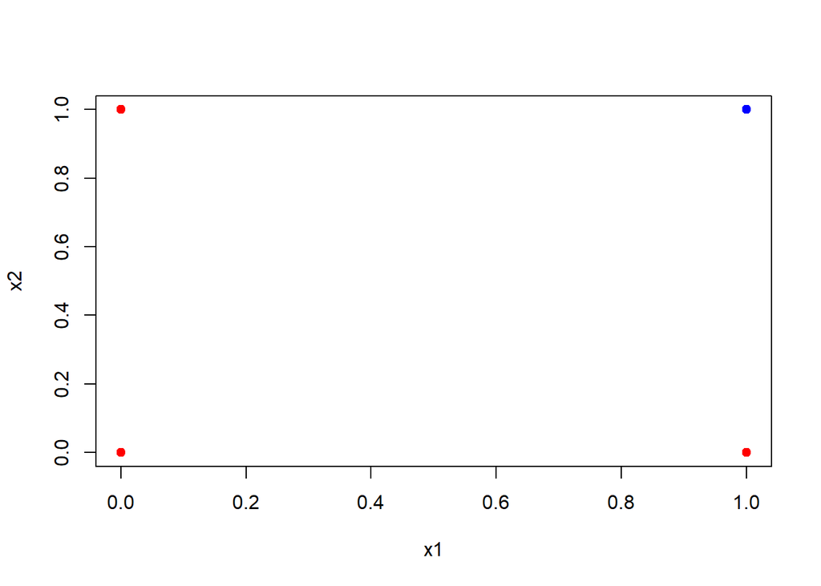

```r
plot(subset(da,y==0)[,1:2],pch=19,col="red")
points(subset(da,y==1)[,1:2],pch=19,col="blue")
```

1. Train single perceptron neural net with no hidden layers. Use `set.seed(14)` for reproducibility.

Answer the following questions:

- Which repetition was best?
- Extract weights of the best repetition
- What is the generated output?
- Reproduce the output of the net manually
2. Modify structure and parameters of perceptron to reproduce results of logistic regression

(Skipped Code)

## 3.3 Example. Predicting Baseball Players’ Salaries

This example is based on the Hitters data from the ISLR library.

```r
library(ISLR)
library(knitr)
```

```r
# Remove incomplete cases
Hitters <- na.omit(Hitters)
# log transform Salary to make it a bit more normally distributed
Hitters$Salary <- log(Hitters$Salary)
kable(head(Hitters,3))
```

|  | AtBat | Hits | HmRun | Runs | RBI | Walks | Years | CAtBat | CHits | CHmRun | CRuns | CRBI | CWalks | League | Division | PutOuts | Assists | Errors | Salary | NewLeague |
| --- | --- | --- | --- | --- | --- | --- | --- | --- | --- | --- | --- | --- | --- | --- | --- | --- | --- | --- | --- | --- |
| -Alan Ashby | 315 | 81 | 7 | 24 | 38 | 39 | 14 | 3449 | 835 | 69 | 321 | 414 | 375 | N | W | 632 | 43 | 10 | 6.163315 | N |
| -Alvin Davis | 479 | 130 | 18 | 66 | 72 | 76 | 3 | 1624 | 457 | 63 | 224 | 266 | 263 | A | W | 880 | 82 | 14 | 6.173786 | A |
| -Andre Dawson | 496 | 141 | 20 | 65 | 78 | 37 | 11 | 5628 | 1575 | 225 | 828 | 838 | 354 | N | E | 200 | 11 | 3 | 6.214608 | N |

Begin with the model with two predictors.

```r
(smallFormula = formula(Salary~Hits+Years))
```

```
## Salary ~ Hits + Years
```

Compare neural network with linear regression and learn the visualization tools implemented in the package.

Load **neuralnet** and train the model using the `neuralnet()` function.

```r
set.seed(0)
nnHit <- neuralnet(smallFormula,data=Hitters,
                  hidden=c(7), err.fct="sse")
names(nnHit)
```

```
##  [1] "call"                "response"            "covariate"
##  [4] "model.list"          "err.fct"             "act.fct"
##  [7] "linear.output"       "data"                "exclude"
## [10] "net.result"          "weights"             "generalized.weights"
## [13] "startweights"        "result.matrix"
```

```r
summary(nnHit)
```

```
##                     Length Class      Mode
## call                  5    -none-     call
## response            263    -none-     numeric
## covariate           526    -none-     numeric
## model.list            2    -none-     list
## err.fct               1    -none-     function
## act.fct               1    -none-     function
## linear.output         1    -none-     logical
## data                 20    data.frame list
## exclude               0    -none-     NULL
## net.result            1    -none-     list
## weights               1    -none-     list
## generalized.weights   1    -none-     list
## startweights          1    -none-     list
## result.matrix        32    -none-     numeric
```

Parameter `hidden` is a vector specifying the number of hidden layers and hidden neurons in each layer. For example vector `c(4,2)` indicates a neural network with two hidden layers, the first layer consists of 4 neurons, the second consists of 2 neurons.

Parameter `err.fct` is a differentiable error function. Strings “sse” or “ce” that are possible values refer to ‘sum of squared errors’ (regression) and ‘cross entropy’ (classification). Default: “sse”.

If necessary print summary (long output not shown).

```r
print(nnHit)
```

The trained neural network can be plotted by

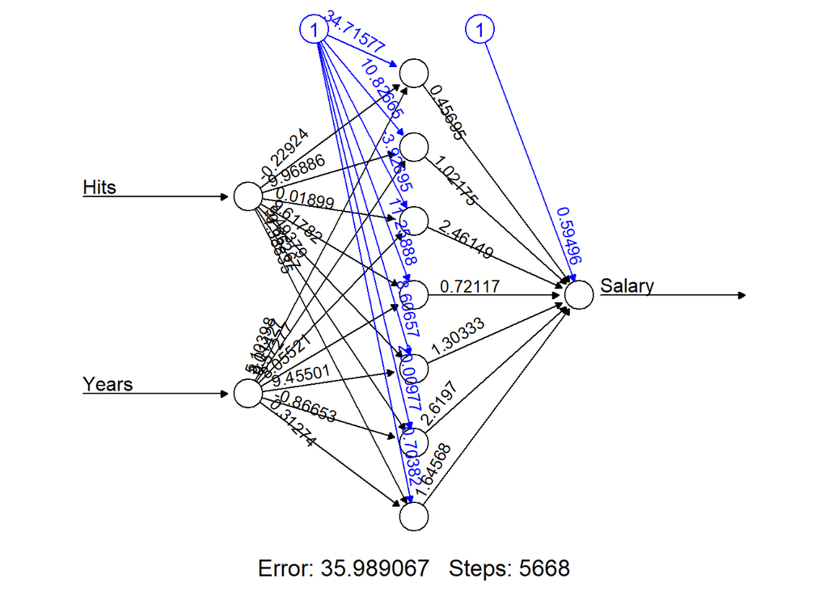

```r
plot(nnHit, rep="best")
```

where `rep` is the number of repetition of the neural network.  
If rep=“best”, the repetition with the smallest error will be plotted.  
If `rep` is not specified all repetitions are plotted, each in a separate terminal window.  
The plot displays the structure of the trained neural network. It includes by default the trained weights, all intercepts (blue) as well as basic information about the training process like the overall error and the number of steps needed to converge.

The list `nnHit$result.matrix` contains main results of the neural network.

```r
nnHit$result.matrix
```

```
##                                [,1]
## error                  3.598907e+01
## reached.threshold      9.861414e-03
## steps                  5.668000e+03
## Intercept.to.1layhid1  3.471577e+01
## Hits.to.1layhid1      -2.292407e-01
## Years.to.1layhid1      5.103976e+00
## Intercept.to.1layhid2  1.082665e+01
## Hits.to.1layhid2       9.968864e+00
## Years.to.1layhid2      8.014273e+00
## Intercept.to.1layhid3 -3.926951e+00
## Hits.to.1layhid3       1.898947e-02
## Years.to.1layhid3      5.727706e-01
## Intercept.to.1layhid4  1.125888e+01
## Hits.to.1layhid4       9.617816e+00
## Years.to.1layhid4      8.055213e+00
## Intercept.to.1layhid5  8.606566e+00
## Hits.to.1layhid5       9.493791e+00
## Years.to.1layhid5      9.455008e+00
## Intercept.to.1layhid6  2.000977e+01
## Hits.to.1layhid6      -6.626728e-01
## Years.to.1layhid6     -8.665341e-01
## Intercept.to.1layhid7  7.038232e-01
## Hits.to.1layhid7      -1.388349e+00
## Years.to.1layhid7      3.127365e-01
## Intercept.to.Salary    5.949597e-01
## 1layhid1.to.Salary     4.569543e-01
## 1layhid2.to.Salary     1.021754e+00
## 1layhid3.to.Salary     2.461487e+00
## 1layhid4.to.Salary     7.211720e-01
## 1layhid5.to.Salary     1.303333e+00
## 1layhid6.to.Salary     2.619702e+00
## 1layhid7.to.Salary     1.645682e+00
```

It shows, for example, that all absolute partial derivatives of the error function became smaller than 0.01 (the default value) after 5668 steps.  
The estimated weights and intercepts can also be obtained from this list. For instance the intercept of the output layer is equal to 0.5949597.

The vector of fitted values, is provided by `nnHit$net.result[[1]]`.

So, MSE equals

```r
(nnMSE = mean((nnHit$net.result[[1]]-Hitters$Salary)^2))
```

```
## [1] 0.2736811
```

Compare the results with linear model

```r
lmHit <- lm(smallFormula,data=Hitters)
lmMSE = sum(lmHit$residuals^2)/nrow(Hitters)
print(list(nnMSE=nnMSE,lmMSE=lmMSE))
```

```
## $nnMSE
## [1] 0.2736811
##
## $lmMSE
## [1] 0.4079477
```

Neural network is more accurate, but has many more parameters. The total number of parameters including all weights and intercepts is

```r
sum(sapply(nnHit$weights[[1]],length))
```

```
## [1] 29
```

Now include all variables in the model. Two important changes should be done in this case.

- Unfortunately `neuralnet()` does not understand the notation `Salary~.`. The predictors need to be listed directly.
- Some columns of the data set are factors. Since `neuralnet()` can handle only numeric variables, convert factors to numeric format with `data.matrix()`.

```r
hitFormula = paste("Salary", paste(names(Hitters)[-match("Salary", names(Hitters))],
                                         collapse = '+'),sep="~")
hitFormula
```

```
## [1] "Salary~AtBat+Hits+HmRun+Runs+RBI+Walks+Years+CAtBat+CHits+CHmRun+CRuns+CRBI+CWalks+League+Division+PutOuts+Assists+Errors+NewLeague"
```

Train the model with the same hidden layer as above.

```r
set.seed(0)
nnHit <- neuralnet(hitFormula,data=data.matrix(Hitters),
                    hidden=7, err.fct="sse")
cat('MSE = ',sum((nnHit$net.result[[1]]-Hitters$Salary)^2)/nrow(Hitters),'\n')
```

```
## MSE =  0.3764201
```

Note that increasing the number of predictors did not improve result. The reason is that minimizing the function of many variables on non-convex set the algorithm stops at a local minimum and does not reach the global one.

Train model with two hidden layers, 5 neurons in the first level and 4 in the second level.  
Set seed to 11.

(Skipped Code)

```
## MSE =  0.3564717
```

## 3.4 Example. Galton’s data

Galton’s data on the heights of parents and their children can be found in the package **HistData**. This data set lists the individual observations for 934 children in 205 families on which Galton (1886) based his cross-tabulation.

```r
library(HistData)
data(GaltonFamilies)
```

Families are largely listed in descending order of fathers and mothers height. Shuffle them to ensure correct cross validation procedure further on.

```r
set.seed(0)
data = GaltonFamilies[sample(nrow(GaltonFamilies)),
                   -which(names(GaltonFamilies) %in% c("family","midparentHeight"))]
data$gender = as.integer(data$gender)
kable(head(data,5))
```

|  | father | mother | children | childNum | gender | childHeight |
| --- | --- | --- | --- | --- | --- | --- |
| 398 | 70.0 | 61.0 | 2 | 2 | 2 | 67.0 |
| 836 | 66.5 | 62.5 | 7 | 5 | 1 | 62.5 |
| 679 | 68.5 | 63.5 | 1 | 1 | 2 | 68.2 |
| 129 | 71.0 | 69.0 | 5 | 2 | 2 | 74.0 |
| 930 | 62.0 | 66.0 | 3 | 1 | 2 | 64.0 |

We removed family number and midparentHeight, which is actually linear combination of parents’ height: `midparentHeight = (father + 1.08*mother)/2`.  
Character variable `gender` was transformed to numeric.

Convergence of neural networks is usually faster if the input variables are normalized to have zero mean and unit variance (see, for example, [Efficient BackProp](http://yann.lecun.com/exdb/publis/pdf/lecun-98b.pdf)).  
One exception to scaling all covariances to the same average and variance occurs when it is known that some inputs are of less significance than others. In such a case, it can be beneficial to scale the less significant inputs down so that they are “less visible” to the learning process.

Scaling of data for neural networks is often different from traditional z-scoring. Because output of perceptron is filtered by a sigmoid activation function it will be scaled between zero and one. This makes centering each variable at minimum and scaling it by range (max-min) more convenient.

```r
mins<-apply(data,2,min)
maxs<-apply(data,2,max)
scaledData = data.frame(scale(data, center = mins, scale = maxs - mins))
```

### 3.4.1 Predicting child’s height by neural network with conventional design

Now perform neural network training using **caret**.  
Load the package and partition data set into train and test subsets.

```r
library(caret)
```

```r
set.seed(0)
inTraining <- createDataPartition(data[,1], p = .8, list = FALSE)
train <- scaledData[ inTraining,]
test  <- scaledData[-inTraining,]
formulaG = formula(childHeight ~ father+mother+children+childNum+gender)
```

Train neural network with one hidden layer using 3-fold cross validation.  
Select number of neurons in single hidden layer by grid search between 3 and 7.  
Recall that the rule of thumb size of hidden layer is defined as average between sizes of input and output layers: $\frac{5+1}{2}=3$.

```r
ctrl <- trainControl(method = "cv", number = 3, returnResamp = "final")
tStart<-proc.time()
set.seed(0)
nnGTrain <- train(formulaG, data = train, method = "neuralnet",
                  trControl = ctrl,
                  tuneGrid = data.frame(layer1 = 3:7, layer2 = 0, layer3 = 0),
                  stepmax = 1e5)
tEnd<-proc.time()
(TimeSpent_1<-tEnd-tStart)
```

```
##    user  system elapsed
##   18.41    0.04   18.64
```

Print summary and plot the final network

```r
print(nnGTrain)
```

```
## Neural Network
##
## 749 samples
##   5 predictor
##
## No pre-processing
## Resampling: Cross-Validated (3 fold)
## Summary of sample sizes: 500, 499, 499
## Resampling results across tuning parameters:
##
##   layer1  RMSE        Rsquared   MAE
##   3       0.08178393  0.7307338  0.06480207
##   4       0.08138255  0.7333429  0.06456108
##   5       0.08159123  0.7321127  0.06447443
##   6       0.08215303  0.7286053  0.06488013
##   7       0.08129085  0.7341264  0.06419501
##
## Tuning parameter 'layer2' was held constant at a value of 0
## Tuning
##  parameter 'layer3' was held constant at a value of 0
## RMSE was used to select the optimal model using the smallest value.
## The final values used for the model were layer1 = 7, layer2 = 0 and layer3 = 0.
```

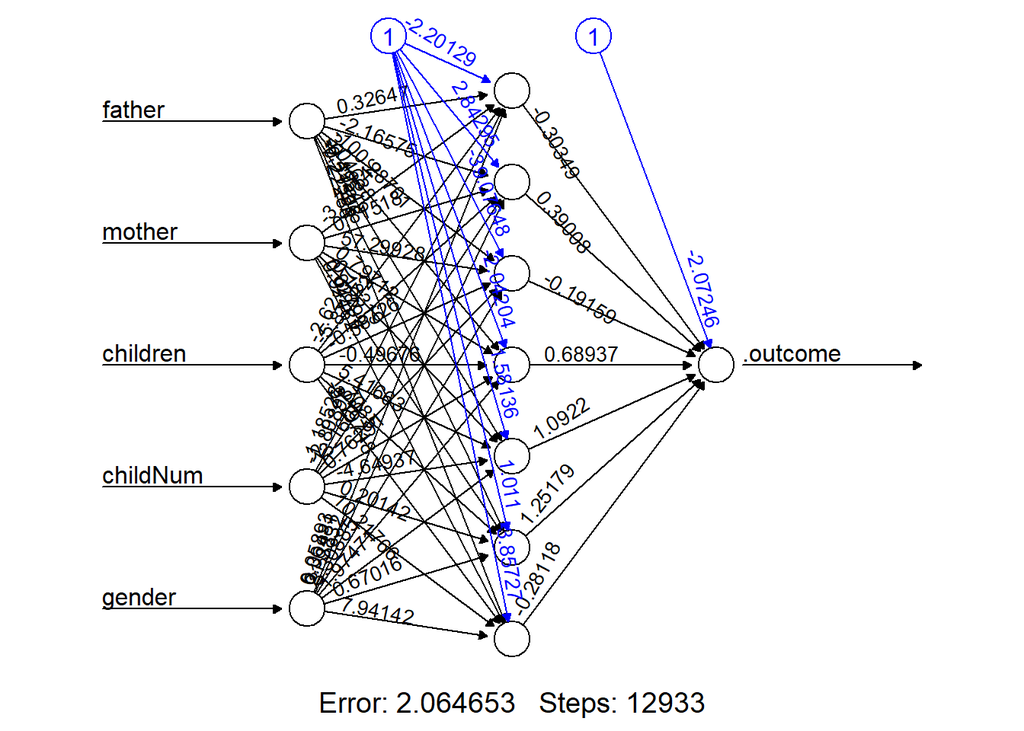

```r
plot(nnGTrain$finalModel,rep="best")
```

Compare results with linear regression.

```r
lmFit <- lm(formulaG, data = train)
pr.lm.train<-lmFit$fitted.values
pr.lm.test<-predict(lmFit,test)
pr.nn.train<-predict(nnGTrain,train)
pr.nn.test<-predict(nnGTrain,test)
compare <- data.frame(lm_MSE=c(mean(lmFit$residuals^2),
                              mean((pr.lm.test-test$childHeight)^2)),
                     nn_MSE=c(mean((pr.nn.train-train$childHeight)^2),
                              mean((pr.nn.test-test$childHeight)^2)) )
rownames(compare) <- c('train','test')
print(compare)
```

```
##            lm_MSE      nn_MSE
## train 0.007092610 0.005513093
## test  0.007601457 0.007929724
```

To calculate predictions from the trained network in the original format unscale the predictions obtained by `compute()`

```r
pr.nn.test <- pr.nn.test*(max(train$childHeight)-min(train$childHeight))+min(train$childHeight)
```

Plot predictions against the actual response values.

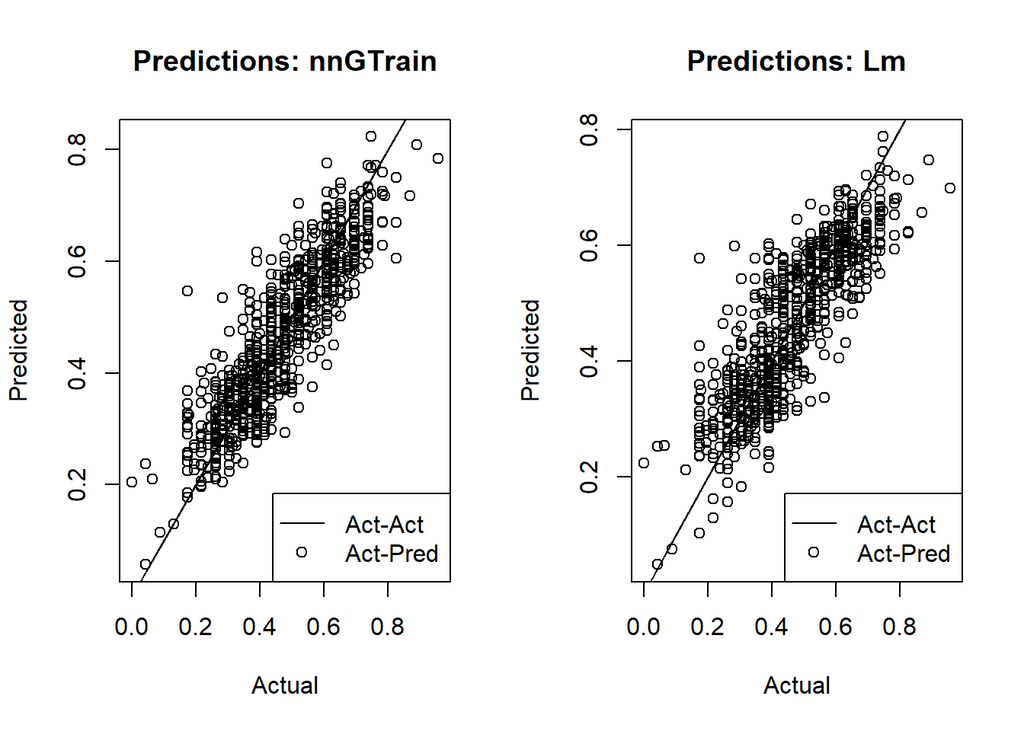

```r
par(mfrow=c(1,2))
plot(train$childHeight,pr.nn.train,main="Predictions: nnGTrain",xlab="Actual",ylab="Predicted")
lines(train$childHeight,train$childHeight)
legend("bottomright",legend=c("Act-Act","Act-Pred"),col="black",pch=c(NA,1),lty=c(1,NA))
plot(train$childHeight,pr.lm.train,main="Predictions: Lm",xlab="Actual",ylab="Predicted")
lines(train$childHeight,train$childHeight)
legend("bottomright",legend=c("Act-Act","Act-Pred"),col="black",pch=c(NA,1),lty=c(1,NA))
```

```r
par(mfrow=c(1,1))
```

### 3.4.2 Simplify the network

**Is it possible to make a simpler neural network model that will also be competitive with linear model?**

Train model with the same formula, no hidden layers and structure as close to linear model as possible.

```r
tStart<-proc.time()
nnGTrainSimple <- neuralnet(formulaG,data=train, err.fct="sse",exclude=c(7,8),
                            constant.weights = c(0,1),rep=5,
                            threshold=1e-5,linear.output=T)
tEnd<-proc.time()
(TimeSpent_1<-tEnd-tStart)
```

```
##    user  system elapsed
##    0.61    0.00    0.62
```

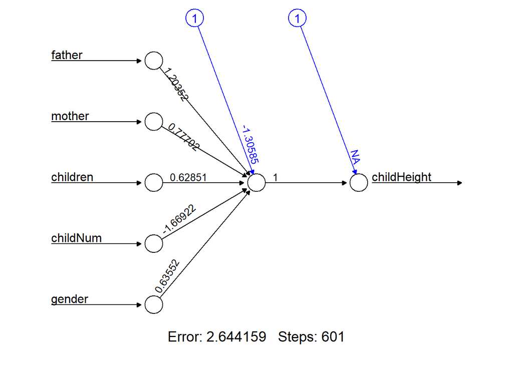

```r
bestRep<-which.min(nnGTrainSimple$result.matrix[1,])
plot(nnGTrainSimple,rep=bestRep)
```

This configuration has only 6 parameters, just as many as the linear model has.

```r
pr.nn.simple.train<-compute(nnGTrainSimple,train[,-6],rep=bestRep)[[1]][[2]][,2]
pr.nn.simple.test<-compute(nnGTrainSimple,test[,-6],rep=bestRep)[[1]][[2]][,2]
compare = data.frame(lm_MSE=c(mean(lmFit$residuals^2),
                              mean((pr.lm.test-test$childHeight)^2)),
                     nn_MSE=c(mean((pr.nn.train-train$childHeight)^2),
                              mean((pr.nn.test-test$childHeight)^2)),
                     nn_MSE.Simple=c(mean((pr.nn.simple.train-train$childHeight)^2),
                                    mean((pr.nn.simple.test-test$childHeight)^2)))
compare
```

```
##        lm_MSE      nn_MSE nn_MSE.Simple
## 1 0.007092610 0.005513093   0.007060505
## 2 0.007601457 0.008457233   0.007532792
```

Compare complexity and performance of the two models.

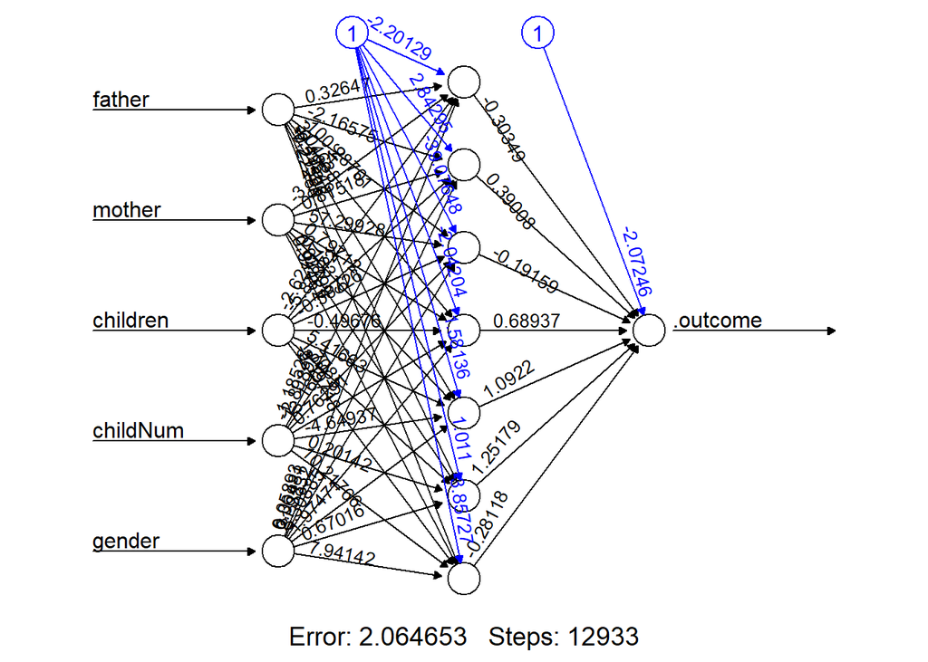

```r
plot(nnGTrain$finalModel,rep="best")
```

Plot and compare actual and predicted values for all 3 models.

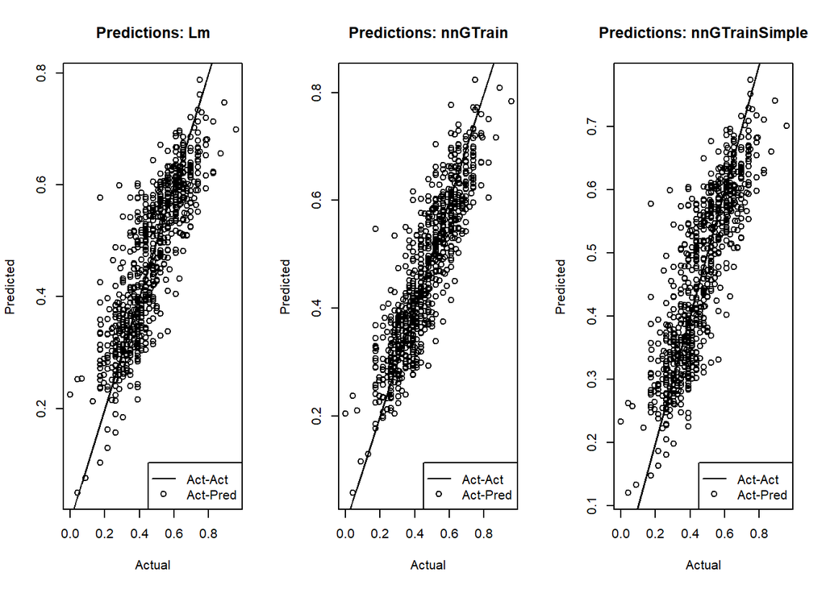

```r
par(mfrow=c(1,3))
plot(train$childHeight,pr.lm.train,main="Predictions: Lm",xlab="Actual",ylab="Predicted")
lines(train$childHeight,train$childHeight)
legend("bottomright",legend=c("Act-Act","Act-Pred"),col="black",pch=c(NA,1),lty=c(1,NA))
plot(train$childHeight,pr.nn.train,main="Predictions: nnGTrain",xlab="Actual",ylab="Predicted")
lines(train$childHeight,train$childHeight)
legend("bottomright",legend=c("Act-Act","Act-Pred"),col="black",pch=c(NA,1),lty=c(1,NA))
plot(train$childHeight,pr.nn.simple.train,main="Predictions: nnGTrainSimple",xlab="Actual",ylab="Predicted")
lines(train$childHeight,train$childHeight)
legend("bottomright",legend=c("Act-Act","Act-Pred"),col="black",pch=c(NA,1),lty=c(1,NA))
```

```r
par(mfrow=c(1,1))
```

# 4 Classification

## 4.1 Example. Galton’s data

Now use Galton’s data in classification example.

```r
data(GaltonFamilies)
set.seed(0)
Data <- GaltonFamilies[sample(nrow(GaltonFamilies)),
                      c("midparentHeight","childHeight","gender")]
kable(head(Data,5))
```

|  | midparentHeight | childHeight | gender |
| --- | --- | --- | --- |
| 398 | 67.94 | 67.0 | male |
| 836 | 67.00 | 62.5 | female |
| 679 | 68.54 | 68.2 | male |
| 129 | 72.76 | 74.0 | male |
| 930 | 66.64 | 64.0 | male |

Look at the data scatterplot.

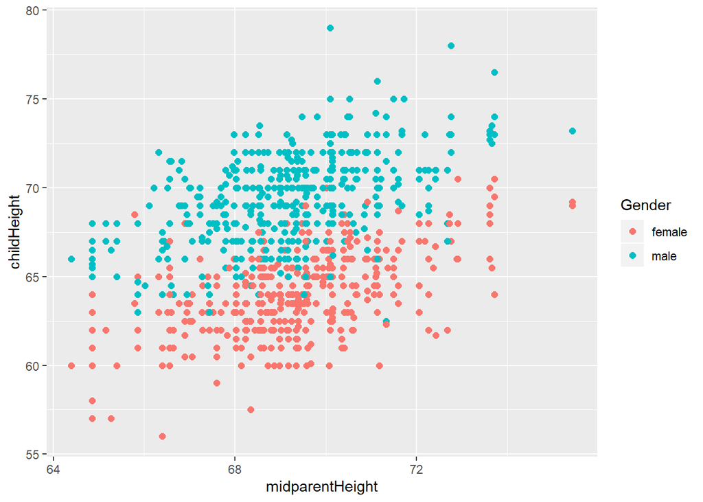

```r
library(ggplot2)
Gender <- as.character(Data$gender)
ggplot(Data, aes(x=midparentHeight, y=childHeight, color=Gender)) + geom_point(shape=16,size=2)
```

Recall that logistic regression classification accuracy of these data, calculated in the lecture on decision trees was 0.881.

Though `Data$gender` is a factor with two levels, `neuralnet()` cannot accept it as response and gives diagnostics  
**“`err.fct` was automatically set to sum of squared error (sse), because the response is not binary”**.

Create binary proxy for `gender`.

```r
Data$male <- Data$gender=="male"
```

Scale input variables

```r
Data$scaledMidParHeight <- scale(Data$midparentHeight,center=min(Data$midparentHeight),
                                 scale=diff(range(Data$midparentHeight)))
Data$scaledChildHeight = scale(Data$childHeight,center=min(Data$childHeight),
                               scale=diff(range(Data$childHeight)))
```

Partition data into train ($\frac{2}{3}$) and test ($\frac{1}{3}$) sets.

```r
set.seed(17)
testInd <- sample(nrow(Data), trunc(nrow(Data)/3))
train <- Data[-testInd,]
test <- Data[testInd,]
```

Fit the model with 7 neurons in one hidden layer to the train set. The error function to be chosen in this case is cross entropy `err.fct="ce"`.

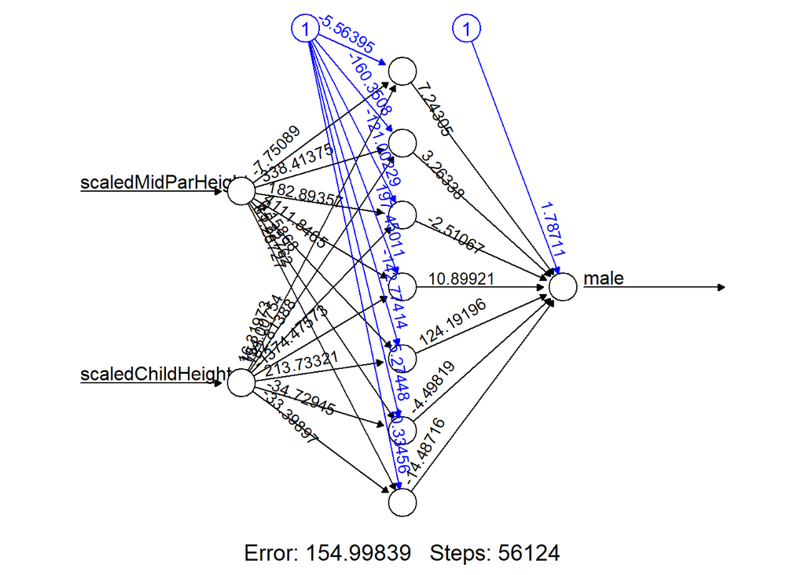

```r
set.seed(0)
nnFit <- neuralnet(male~scaledMidParHeight+scaledChildHeight,
                   data = train, err.fct = "ce",
                   hidden = 7, threshold = 0.01,
                   linear.output=FALSE)
plot(nnFit,rep="best")
```

Predict classes using the test set. Use method `compute()` for prediction. It computes the outputs of all neurons for specific arbitrary covariate vectors given a trained neural network.

Remember to make the order of the covariates the same in the new matrix or data frame as in the original neural network.

Note that in spite of using formula in `neuralnet()` call we cannot put, for example, `train` or `test` data frames as arguments.  
We have to remove unused columns from these data frames.

```r
predict <- (compute(nnFit,test[c("scaledMidParHeight",
                                "scaledChildHeight")])$net.result > 0.5)*1
head(predict)
```

```
##     [,1]
## 244    0
## 316    0
## 208    1
## 62     0
## 396    0
## 743    1
```

Show the scatterplot with misclassified test points (black).

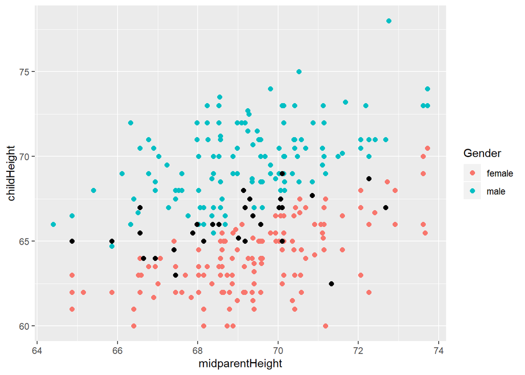

```r
Gender = as.character(test$gender)
misclassified = (predict != test[,"male"])
ggplot(data=test, aes(x=midparentHeight, y=childHeight,
                  color=Gender))+geom_point(shape=16,size=2)+
  geom_point(data=test[misclassified,],
             aes(x=midparentHeight, y=childHeight), colour="black", size=2)
```

The function `table()` returns confusion matrix.

```r
(conf <- table(pred = predict, true = test[,"male"]))
```

```
##     true
## pred FALSE TRUE
##    0   141   18
##    1    14  138
```

The prediction accuracy can be computed by

```r
(accuracy = (conf[1,1]+conf[2,2])/sum(conf))
```

```
## [1] 0.8971061
```

The accuracy is almost the same as of logistic regression but the model has many more parameters.

Here is the comparison with logistic regression.

```r
logModelFormula = formula('gender ~ scaledMidParHeight+scaledChildHeight')
logrFit <- glm(logModelFormula, family=binomial("logit"),data=train)
summary(logrFit)
```

```
##
## Call:
## glm(formula = logModelFormula, family = binomial("logit"), data = train)
##
## Deviance Residuals:
##     Min       1Q   Median       3Q      Max
## -3.0540  -0.3656   0.0493   0.3019   3.7157
##
## Coefficients:
##                    Estimate Std. Error z value Pr(>|z|)
## (Intercept)         -7.0831     0.7051 -10.046  < 2e-16 ***
## scaledMidParHeight  -8.3275     1.0446  -7.972 1.56e-15 ***
## scaledChildHeight   23.5270     1.8559  12.677  < 2e-16 ***
## ---
## Signif. codes:  0 '***' 0.001 '**' 0.01 '*' 0.05 '.' 0.1 ' ' 1
##
## (Dispersion parameter for binomial family taken to be 1)
##
##     Null deviance: 862.49  on 622  degrees of freedom
## Residual deviance: 343.61  on 620  degrees of freedom
## AIC: 349.61
##
## Number of Fisher Scoring iterations: 6
```

```r
predLogrFit<-predict(logrFit,test,type="response")>.5
confLogr<-table(pred = predLogrFit, true = test[,"male"])
accuracyLogr = (confLogr[1,1]+confLogr[2,2])/sum(confLogr)
c(NN=accuracy,Logr=accuracyLogr)
```

```
##        NN      Logr
## 0.8971061 0.8874598
```

Try to reduce complexity of the net.  
The hidden code below fits 2 simplified versions of the model called `nnFitSimple1` and `nnFitSimple2`. Try to define your own simplified architectures.

(Skipped code)

```r
predictSimple1 <- (compute(nnFitSimple1,test[c("scaledMidParHeight",
                                "scaledChildHeight")])$net.result > 0.5)*1
(confSimple1 <- table(pred = predictSimple1, true = test[,"male"]))
```

```
##     true
## pred FALSE TRUE
##    0   139   19
##    1    16  137
```

```r
(accuracySimple1 <- (confSimple1[1,1]+confSimple1[2,2])/sum(confSimple1))
```

```
## [1] 0.8874598
```

```r
predictSimple2 <- (compute(nnFitSimple2,test[c("scaledMidParHeight",
                                "scaledChildHeight")])$net.result > 0.5)*1
(confSimple2 <- table(pred = predictSimple2, true = test[,"male"]))
```

```
##     true
## pred FALSE TRUE
##    0   139   19
##    1    16  137
```

```r
(accuracySimple2 <- (confSimple2[1,1]+confSimple2[2,2])/sum(confSimple2))
```

```
## [1] 0.8874598
```

```r
c(NN=accuracy,NNSimple1=accuracySimple1,NNSimple2=accuracySimple2,Logr=accuracyLogr)
```

```
##        NN NNSimple1 NNSimple2      Logr
## 0.8971061 0.8874598 0.8874598 0.8874598
```

## 4.2 Example. Rectangular class domain

Simulate the data with another shape of classes. Each observation is three-dimensional vector with two numeric features and one categorical (type) with possible values ‘Positive’ or ‘Negative’. The problem is to identify type on the basis of first two features.

```r
N = 1000
xPos = 0.2
yMinPos = 0.2
yMaxPos = 0.7
set.seed(0)
newData = data.frame(y=runif(N),x=runif(N))
newData$type = with(newData,x>xPos & y>yMinPos & y<yMaxPos)
n = N/10
newData$type[1:n] = c(TRUE,FALSE)[1+rbinom(n, 1, 0.5)]
```

Add some noise at the beginning of the data and shuffle.

```r
n = N/10
newData$type[1:n] = c(TRUE,FALSE)[1+rbinom(n, 1, 0.5)]
newData = newData[sample(nrow(newData)),]
```

Plot the data

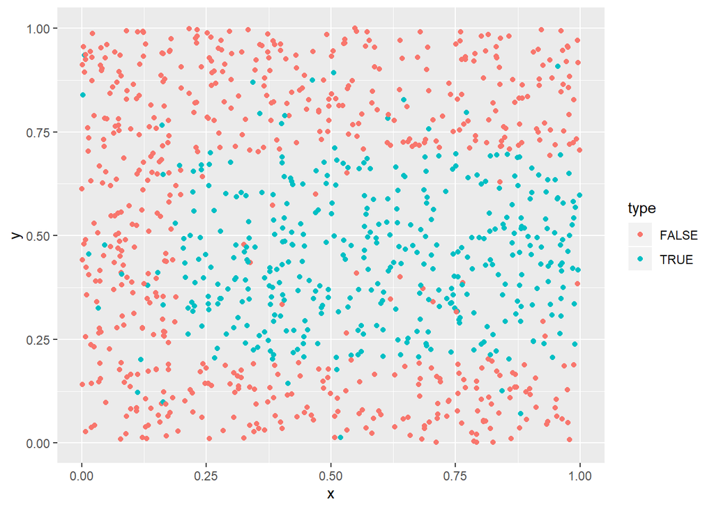

```r
library(ggplot2)
library(neuralnet)
rect <- ggplot(newData, aes(x=x, y=y, color=type)) + geom_point(shape=16)
#+ scale_color_hue(l=50)
rect
```

Partition the data into train (2/3) and test (1/3) sets.  
Fit neural net with one hidden layer to the train data and estimate prediction accuracy on the test data.  
Use `set.seed(11)` to make test and train data. Also do `set.seed(1)` before running `neuralnet()`.

(Skipped Code)

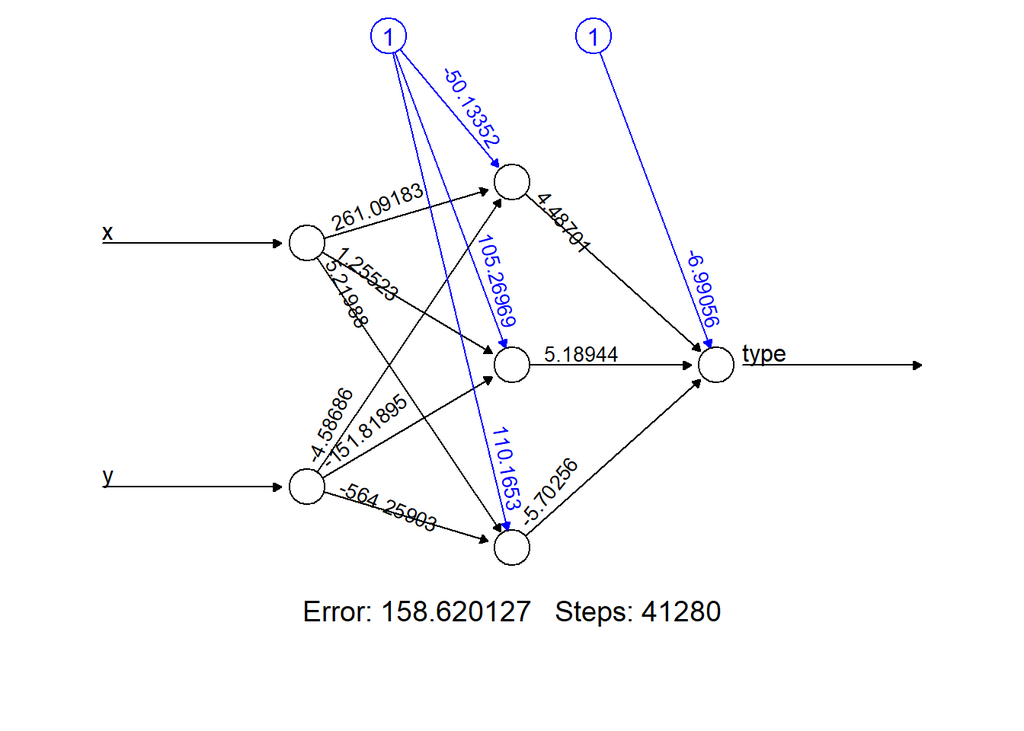

```r
plot(nnFit,rep="best")
```

```r
conf
```

```
##        true
## pred    FALSE TRUE
##   FALSE   198    9
##   TRUE      6  120
```

```r
accuracy
```

```
## [1] 0.954955
```

Plot the class domain estimation.  
An easy way of doing it is giving a lot of points (not necessarily random) filling the unit square as the input to the fitted net. It is not necessary to scale the data since they are already between zero and one.

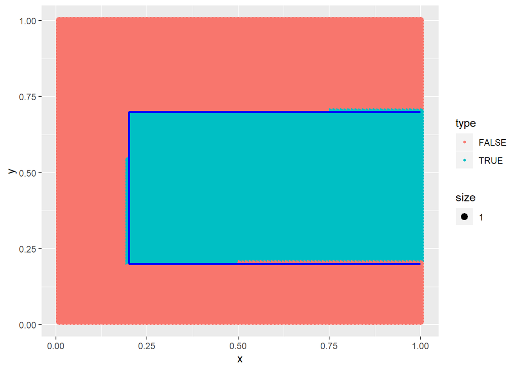

```r
tmp <- data.frame(t(combn(c(1:100,100:1)*0.01, 2)))
names(tmp) = c('x','y')
tmp$type <- compute(nnFit,tmp)$net.result > 0.5
domain <- ggplot(data=tmp, aes(x=x, y=y, color=type,size=1)) +
  geom_point(shape=20)
domain <- domain  + geom_segment(aes(x = xPos, y = yMaxPos,xend = 1,yend = yMaxPos), colour= "blue",size=1)
domain <- domain + geom_segment(aes(x = 1,y=yMinPos,yend=yMinPos,xend=xPos), colour= "blue",size=1)
domain <- domain + geom_segment(aes(x = xPos, y = yMinPos,xend = xPos,yend = yMaxPos), colour= "blue",size=1)
domain
```

Neural network shows the accuracy similar to trees and SVM in this example.  
The estimated class domain is very close to the simulated class (blue line).

Again, the main problem is the number of parameters.

```r
nnFit$weights
```

```
## [[1]]
## [[1]][[1]]
##            [,1]        [,2]       [,3]
## [1,] -50.133517  105.269690  110.16530
## [2,] 261.091827    1.255235    5.21988
## [3,]  -4.586858 -151.818951 -564.25903
##
## [[1]][[2]]
##           [,1]
## [1,] -6.990555
## [2,]  4.487012
## [3,]  5.189438
## [4,] -5.702558
```

## 4.3 Otto Product Classification Example

Turn again to Otto Product Classification example.  
Assign a path to `DTTrain.csv` to variable `datapath`.

Load the data set.

```r
library(fBasics)
Data = read.csv(paste(datapath,'DTTrain.csv',sep='/'),header=TRUE,
                stringsAsFactors = TRUE)
dim(Data) # dataset dimensions
```

```
## [1] 10233    95
```

```r
# data content
kable(head(Data[,1:5],3))
```

| time | feat_1 | feat_2 | feat_3 | feat_4 |
| --- | --- | --- | --- | --- |
| 45652 | 0 | 0 | 0 | 0 |
| 225646 | 0 | 0 | 0 | 0 |
| 345735 | 0 | 0 | 0 | 0 |

```r
kable(Data[1:3,(ncol(Data)-4):ncol(Data)])
```

| feat_90 | feat_91 | feat_92 | feat_93 | target |
| --- | --- | --- | --- | --- |
| 0 | 0 | 1 | 0 | Class_5 |
| 0 | 1 | 1 | 0 | Class_3 |
| 0 | 0 | 0 | 0 | Class_5 |

Partition data into train ($\frac{2}{3}$) and test ($\frac{1}{3}$) sets.

```r
set.seed(0)
testInd = sample(nrow(Data), trunc(nrow(Data)/3))
trainX = Data[-testInd,-c(1,ncol(Data))]
trainY = Data$target[-testInd]
testX = Data[testInd,-c(1,ncol(Data))]
testY = Data$target[testInd]
```

Fit neural network with one hidden layer. Tune the number of neurons with **caret** using 5-fold cross validation.

```r
ctrl <- trainControl(method = "cv", number = 5, classProbs =  TRUE)
set.seed(0)
nnFitOtto <- train(trainX, trainY, method = "nnet", trControl = ctrl,
                  tuneGrid = expand.grid(.size=3:6,.decay=.3),
                  maxit = 1000, trace = FALSE,
                  preProc = c("center", "scale"))
```

Print results and calculate accuracy.

```r
print(nnFitOtto)
```

```
## Neural Network
##
## 6822 samples
##   93 predictor
##    5 classes: 'Class_1', 'Class_2', 'Class_3', 'Class_4', 'Class_5'
##
## Pre-processing: centered (93), scaled (93)
## Resampling: Cross-Validated (5 fold)
## Summary of sample sizes: 5459, 5457, 5456, 5457, 5459
## Resampling results across tuning parameters:
##
##   size  Accuracy   Kappa
##   3     0.8714452  0.8270622
##   4     0.8790671  0.8372798
##   5     0.8751095  0.8318863
##   6     0.8737949  0.8303905
##
## Tuning parameter 'decay' was held constant at a value of 0.3
## Accuracy was used to select the optimal model using the largest value.
## The final values used for the model were size = 4 and decay = 0.3.
```

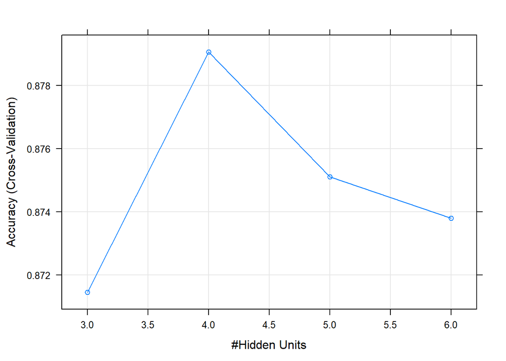

```r
plot(nnFitOtto)
```

```r
conf = table(predict(nnFitOtto, testX,type='raw'), testY)
cat('Accuracy = ',tr(conf)/sum(conf),'\n')
```

```
## Accuracy =  0.887423
```

We also used Multiclass logloss for estimating prediction quality of previous methods. Calculate it for fitted network.

```r
MultiLogLoss <- function(act, pred)
{
  eps = 1e-15;
  pred[pred<eps] = eps
  pred[pred> (1-eps)] = 1-eps
  #normalize rows
  ll = sum(act*log(sweep(pred, 1, rowSums(pred), FUN="/")))
  ll = -ll/nrow(act)
  return(ll);
}

actMatrix = model.matrix(~-1+testY)
print(MultiLogLoss(actMatrix,
                   predict(nnFitOtto,testX,type='prob')))
```

```
## [1] 0.3381823
```

Worse than SVM, but, as was noted in the lecture on SVM, all these methods have many parameters to be tuned in order to improve the results.